# Evènements remarquables 2014

- tensions hospitalières
- pic de pollution: semaine 11 (10-16 mars, circulation alternée Paris le 17/3)
- ponts ?
- congés scolaires ?

## Jours fériés en France

Date Nom Remarques

**1er janvier** Jour de l’an Premier jour de l’année ; Pour les catholiques, fête de Sainte Marie Mère de Dieu (avant le concile Vatican II, Circoncision de Jésus-Christ.)

47ème et 46ème jours avant Pâques Mardi gras et Mercredi des cendres Jours fériés supplémentaires spécifiques aux Antilles

**Vendredi saint** Jour férié chrétien supplémentaire spécifique aux départements de la Moselle, du Bas-Rhin et du Haut-Rhin et des Antilles.

**Lundi de Pâques** Pâques (fête chrétienne commune aux catholiques et aux protestants) est le premier dimanche qui suit la première pleine lune de printemps.

**1er mai** Fête du Travail Commémore la ratification de la journée de travail de 8 heures ; traditionnellement le jour de nombreuses manifestations syndicales et politiques en France. (Depuis 1947, l’appellation “Fête du Travail” n’est que coutumière, i.e. non officielle).

**8 mai** Fête de la Victoire Commémoration de la capitulation de l’Allemagne nazie mettant fin à la Seconde Guerre mondiale en Europe.

22 mai Abolition de l’esclavage Dans le département de la Martinique uniquement

27 mai Abolition de l’esclavage Dans le département de la Guadeloupe uniquement

**Jeudi Ascension** 40 jours après Pâques Fête chrétienne célébrant la montée de Jésus aux cieux

**Lundi de Pentecôte** Le lundi suivant le dimanche de Pentecôte (le septième après Pâques). Fête chrétienne célébrant la descente du Saint-Esprit parmi les apôtres. Même si cette journée est redevenue chômée, le Lundi de Pentecôte fut choisi comme journée de solidarité de 2005 à 2007 (inclus) et devait être considéré comme travaillé (sans rémunération).

10 juin Abolition de l’esclavage Dans le département de la Guyane uniquement

**14 juillet** Fête nationale Commémoration de la Fête de la Fédération du 14 juillet 1790 (elle-même anniversaire de la prise de la Bastille en 1789).

**15 août** Assomption Fête catholique célébrant la montée de la Vierge Marie aux cieux. Fête de Marie, sainte patronne de la France et Fête nationale sous la Monarchie

9 octobre Abolition de l’esclavage Dans collectivité d’outre-mer de Saint-Barthélemy uniquement

**1er novembre** Toussaint Fête de tous les saints de l’Église catholique

2 novembre Fête des Morts Le jour des morts, est à la fois une journée de commémoraison et une journée d’intercession, de prière pour les morts. Jour férié chrétien supplémentaire spécifique aux départements des Antilles.

**11 novembre** Armistice de 1918 Commémoration de l’armistice mettant fin à la Première Guerre mondiale

20 décembre Abolition de l’esclavage Dans le département de la Réunion uniquement

**25 décembre** Noël Naissance de Jésus-Christ

**26 décembre** Saint Étienne Jour férié chrétien supplémentaire spécifique aux départements de la Moselle, du Bas-Rhin et du Haut-Rhin

## Principales fêtes de 2014

```r
library("timeDate")
library("lubridate")

year <- 2014

a<-NewYearsDay()
print(paste("Nouvel an:", wday(a, label=T), a))
```

```
## [1] "Nouvel an: Wed 2014-01-01"
```

```r
a <- Easter(year)
b <- EasterMonday(year)
c <- EasterSunday(year)
d <- GoodFriday(year)
print(paste("Vendredi Saint:", d))
```

```
## [1] "Vendredi Saint: 2014-04-18"
```

```r
print(paste("dimanche de Pâques:", c))
```

```
## [1] "dimanche de Pâques: 2014-04-20"
```

```r
print(paste("lundi de Pâques:", b))
```

```
## [1] "lundi de Pâques: 2014-04-21"
```

```r
a <- FRAllSaints(year)
print(paste("Tousaint:", wday(a, label=T), a))
```

```
## [1] "Tousaint: Sat 2014-11-01"
```

```r
a <- FRArmisticeDay(year)
print(paste("Armistice 1918:", wday(a, label=T), a))
```

```
## [1] "Armistice 1918: Tues 2014-11-11"
```

```r
a <- FRAscension(year)
print(paste("Ascencion:", wday(a, label=T), a))
```

```
## [1] "Ascencion: Thurs 2014-05-29"
```

```r
a <- FRAssumptionVirginMary(year)
print(paste("Assomption:", wday(a, label=T), a))
```

```
## [1] "Assomption: Fri 2014-08-15"
```

```r
a <- FRBastilleDay(year)
print(paste("14 juillet:", wday(a, label=T), a))
```

```
## [1] "14 juillet: Mon 2014-07-14"
```

```r
a <- FRAscension(year)
print(paste("Ascencion:", wday(a, label=T), a))
```

```
## [1] "Ascencion: Thurs 2014-05-29"
```

```r
a <- LaborDay(year)
print(paste("Fête du travail:", wday(a, label=T), a))
```

```
## [1] "Fête du travail: Thurs 2014-05-01"
```

```r
a <- Pentecost(year)
print(paste("Pentecote:", wday(a, label=T), a))
```

```
## [1] "Pentecote: Sun 2014-06-08"
```

```r
a <- PentecostMonday(year)
print(paste("Lundi de pentecote:", wday(a, label=T), a))
```

```
## [1] "Lundi de pentecote: Mon 2014-06-09"
```

Liste des dimanches: - on forme une liste de tous les jours de l’année - on extrait les dimanches (dim) - les samedis (sam) - les jours fériés (ferie) il manque le 26 décembre

```r
library("timeDate")

year <- 2013

y <- timeSequence(from = paste0(year,"-01-01"), to = paste0(year, "-12-31"), by = "day")
y <- as.Date(y)
length(y)
```

```
## [1] 365
```

```r
dim <- y[weekdays(as.Date(y)) == "dimanche"]
sam <- y[weekdays(as.Date(y)) == "samedi"]

length(dim)
```

```
## [1] 52
```

```r
length(sam)
```

```
## [1] 52
```

```r
ferie <- c(Pentecost(year), PentecostMonday(year), LaborDay(year), FRAscension(year), FRBastilleDay(year), FRAssumptionVirginMary(year), FRAscension(year), FRArmisticeDay(year),  FRAllSaints(year), GoodFriday(year), EasterMonday(year), NewYearsDay(year), ChristmasDay(year))
ferie <- as.Date(ferie)
```

Ensemble des jours qui ne sont ni des samedis, ni des dimanches, ni des jours fériés

```r
ouvrable <- y[!match(as.character(y), as.character(dim), nomatch = 0)]
length(ouvrable)
```

```
## [1] 313
```

```r
ouvrable <- ouvrable[!match(as.character(ouvrable), as.character(sam), nomatch = 0)]
length(ouvrable)
```

```
## [1] 261
```

```r
ouvrable <- ouvrable[!match(as.character(ouvrable), as.character(ferie), nomatch = 0)]
length(ouvrable)
```

```
## [1] 251
```

Samedi et dimanche fériés

```r
samedi.ferie <- a <- merge(as.character(sam), as.character(ferie), by=1)
samedi.ferie
```

```
## [1] x
## <0 rows> (or 0-length row.names)
```

```r
dimanche.ferie <- merge(as.character(dim), as.character(ferie), by=1)
dimanche.ferie
```

```
##            x
## 1 2013-05-19
## 2 2013-07-14
```

Jours de semaine fériés

```r
ouvrable <- y[!match(as.character(y), as.character(dim), nomatch = 0)]
ouvrable <- ouvrable[!match(as.character(ouvrable), as.character(sam), nomatch = 0)]
ouvrable.ferie <- merge(as.character(ouvrable), as.character(ferie), by=1)
ouvrable.ferie
```

```
##             x
## 1  2013-01-01
## 2  2013-03-29
## 3  2013-04-01
## 4  2013-05-01
## 5  2013-05-09
## 6  2013-05-09
## 7  2013-05-20
## 8  2013-08-15
## 9  2013-11-01
## 10 2013-11-11
## 11 2013-12-25
```

```r
wday(ouvrable.ferie$x, label = TRUE)
```

```
##  [1] Tues  Fri   Mon   Wed   Thurs Thurs Mon   Thurs Fri   Mon   Wed
## Levels: Sun < Mon < Tues < Wed < Thurs < Fri < Sat
```

Dimanches et jours fériés en Alsace

```r
dim.and.ferie <- c(dim, ouvrable.ferie)
```

# Vacances scolaires 2014

noel2013_debut <- as.Date(“2013-12-22”) noel2013_fin <- as.Date(“2014-01-05”) hiver2014_debut <- “2014-02-23” hiver2014_fin <- “2014-03-09” printemps_debut <- “2014-04-20” printemps_fin <- “2014-05-04” ete_debut <- “2014-07-06” ete_fin <- “2014-09-02” toussaint_debut <- “2014-10-18” toussaint_fin <- “2014-11-03” noel_ debut <- “2014-12-20” noel_fin <- “2015-01-05”

## faire un calendrier

On peut créer une séquence de date avec la fonction **seq** et des objets de type **Date**.

seq(from, to, by, length.out = NULL, along.with = NULL, …)

Arguments:

- from date de départ [obligatoire]
- to date de fin [optionnel].
- by incrément. Il peut être spécifié de différentes manières: - en nombre de jours - un objet de la classe [difftime](https://stat.ethz.ch/R-manual/R-devel/library/base/html/difftime.html) - une chaîne de caractères contenant l’un des mots suivant: “day”, “week”, “month”, “quarter” or “year”. On peut de manière optionnelle faire précéder chacun de ces mots par un entier (positif ou négatif) suivi d’un espace, puis le mot (ex “-1 week” à partir de la date de départ affiche les dates par saut en arrière de 1 semaine)
- length.out nombre entier correspondant à la longueur de la séquence désirée [optionel]
- along.with prend la longueur à partir de la longueur de cet argument

voir [seq.POSIXt](https://stat.ethz.ch/R-manual/R-devel/library/base/html/seq.POSIXt.html) pour les détails de “month”.

Valeur retournée: un vecteur de la classe “Date”.

exemples

```r
# first days of years
seq(as.Date("1910/1/1"), as.Date("1999/1/1"), "years")
```

```
##  [1] "1910-01-01" "1911-01-01" "1912-01-01" "1913-01-01" "1914-01-01"
##  [6] "1915-01-01" "1916-01-01" "1917-01-01" "1918-01-01" "1919-01-01"
## [11] "1920-01-01" "1921-01-01" "1922-01-01" "1923-01-01" "1924-01-01"
## [16] "1925-01-01" "1926-01-01" "1927-01-01" "1928-01-01" "1929-01-01"
## [21] "1930-01-01" "1931-01-01" "1932-01-01" "1933-01-01" "1934-01-01"
## [26] "1935-01-01" "1936-01-01" "1937-01-01" "1938-01-01" "1939-01-01"
## [31] "1940-01-01" "1941-01-01" "1942-01-01" "1943-01-01" "1944-01-01"
## [36] "1945-01-01" "1946-01-01" "1947-01-01" "1948-01-01" "1949-01-01"
## [41] "1950-01-01" "1951-01-01" "1952-01-01" "1953-01-01" "1954-01-01"
## [46] "1955-01-01" "1956-01-01" "1957-01-01" "1958-01-01" "1959-01-01"
## [51] "1960-01-01" "1961-01-01" "1962-01-01" "1963-01-01" "1964-01-01"
## [56] "1965-01-01" "1966-01-01" "1967-01-01" "1968-01-01" "1969-01-01"
## [61] "1970-01-01" "1971-01-01" "1972-01-01" "1973-01-01" "1974-01-01"
## [66] "1975-01-01" "1976-01-01" "1977-01-01" "1978-01-01" "1979-01-01"
## [71] "1980-01-01" "1981-01-01" "1982-01-01" "1983-01-01" "1984-01-01"
## [76] "1985-01-01" "1986-01-01" "1987-01-01" "1988-01-01" "1989-01-01"
## [81] "1990-01-01" "1991-01-01" "1992-01-01" "1993-01-01" "1994-01-01"
## [86] "1995-01-01" "1996-01-01" "1997-01-01" "1998-01-01" "1999-01-01"
```

```r
## by month
seq(as.Date("2000/1/1"), by = "month", length.out = 12)
```

```
##  [1] "2000-01-01" "2000-02-01" "2000-03-01" "2000-04-01" "2000-05-01"
##  [6] "2000-06-01" "2000-07-01" "2000-08-01" "2000-09-01" "2000-10-01"
## [11] "2000-11-01" "2000-12-01"
```

```r
## quarters
seq(as.Date("2000/1/1"), as.Date("2003/1/1"), by = "quarter")
```

```
##  [1] "2000-01-01" "2000-04-01" "2000-07-01" "2000-10-01" "2001-01-01"
##  [6] "2001-04-01" "2001-07-01" "2001-10-01" "2002-01-01" "2002-04-01"
## [11] "2002-07-01" "2002-10-01" "2003-01-01"
```

```r
## find all 7th of the month between two dates, the last being a 7th.
st <- as.Date("1998-12-17")
en <- as.Date("2000-1-7")
ll <- seq(en, st, by = "-1 month")
rev(ll[ll > st & ll < en])
```

```
##  [1] "1999-01-07" "1999-02-07" "1999-03-07" "1999-04-07" "1999-05-07"
##  [6] "1999-06-07" "1999-07-07" "1999-08-07" "1999-09-07" "1999-10-07"
## [11] "1999-11-07" "1999-12-07"
```

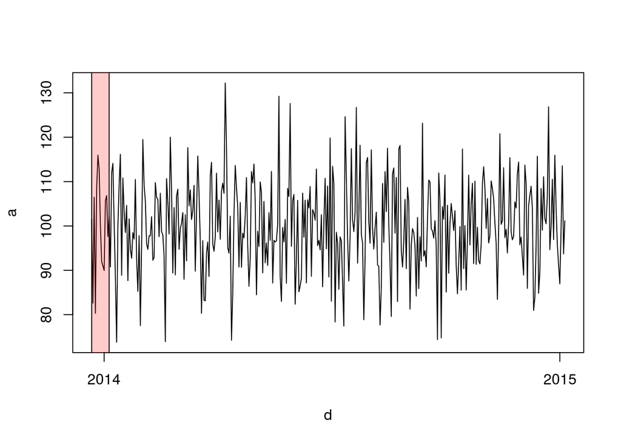

```r
# année 2014 avec les cacances de noel 2013 et 2014
d <- seq(as.Date("2013-12-22"), as.Date("2015-01-05"), 1)
# un vecteur de 380 nombe aléatoire de moyenne 100 et etype 10
a <- rnorm(length(d), 100, 10)
# trace la courbe
plot(d, a, type="l")
# on ajoute des rectangles colorés pour la période des vacances. a métode rgb est nécessaire pour avoir des couleurs semi-transparantes. Le paramètre alpha gère la transparence
rect(as.Date("2013-12-22"), 135, as.Date("2014-01-05"),0, col=rgb(1, 0, 0,0.2))
```

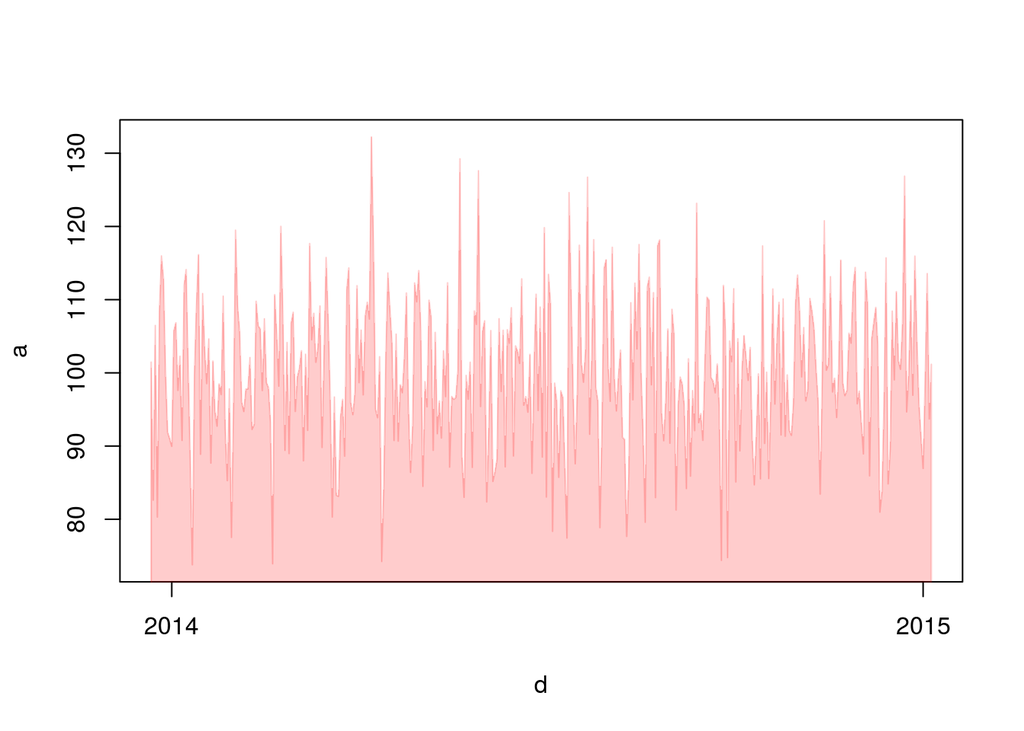

```r
# dessin courbe sous forme d'un polygone coloré. Le polygone nécessite 2 vecteurs, l'un pour les x, l'autre pour les y.
plot(d, a, type = "n") # dessine la courbe sans l'afficher
polygon(c(d[1], d, d[380]), c(0, a, 0), col=rgb(1, 0, 0,0.2), border=rgb(1, 0, 0,0.2))
```

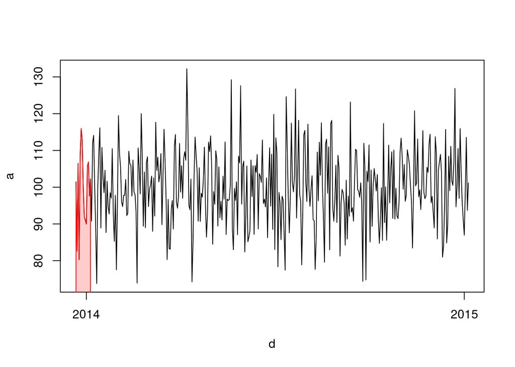

```r
# dessin de la courbe avec un polygone uniquement pendant la période des vacances
plot(d, a, type="l")
noel2013_debut <- as.Date("2013-12-22")
noel2013_fin <- as.Date("2014-01-05")
vacances_noel <- seq(noel2013_debut, noel2013_fin, 1) # vecteur de date
dt <- difftime(noel2013_fin, noel2013_debut) + 1 # longueur des vacances en jour
polygon(c(noel2013_debut, vacances_noel, noel2013_fin), c(0, a[1:dt], 0), col=rgb(1, 0, 0,0.2), border = "red")
```